# Statistical Data Analysis Report

Sujata Biradar

2020-12-07

[figure not shown]

# Introduction

Music is one special language that connects us all together and it has always been a major part of all our lives. We listen to music ALL the time; during our commute, at work, and with friends. Spotify being the biggest streaming platform lists over 50 million songs, as well as over 700,000 podcast titles. For every track on their platform, Spotify provides data for thirteen Audio Features. The motivation of this report is to discover patterns and insights about the music that listeners listen to. In doing so, we can get a better understanding of musical behaviors when we listen to songs on Spotify.

Let’s take a look at the audio features provided by Spotify and how they are read!

- `Danceability`: Describes how suitable a track is for dancing, 0.0 is least danceable and 1.0 is most danceable.
- `Energy`: is a measure from 0.0 to 1.0 and represents a perceptual measure of intensity and activity.
- `Speachiness`: detects the presence of spoken words in a track. Values above 0.66 describe tracks that are probably made entirely of spoken words.
- `Acousticness`: A confidence measure from 0.0 to 1.0 of whether the track is acoustic
- `Liveness`: Higher liveness values represent an increased probability that the track was performed live.
- `Valence`: A measure from 0.0 to 1.0 describing the musical positiveness conveyed by a track. Tracks with high valence sound more positive (e.g. happy, cheerful, euphoric).
- `Key`: The estimated overall key of the track. Integers map to pitches using standard Pitch Class notation . E.g. 0 = C, 1 = C♯/D♭, 2 = D, and so on.
- `Mode`: Indicates the modality (major or minor) of a track, the type of scale from which its melodic content is derived. Major is represented by 1 and minor is 0.
- `Duration`:The duration of the track in milliseconds- transformed later to seconds
- `Time Signature`: An estimated overall time signature of a track. The time signature (meter) is a notational convention to specify how many beats are in each bar (or measure).

# Exploratory Data Analysis

As a part of initial data exploration, first I looked at the correlation of all the audio features and track popularity as a starting point. This helped me understand few interesting associations at a glance.

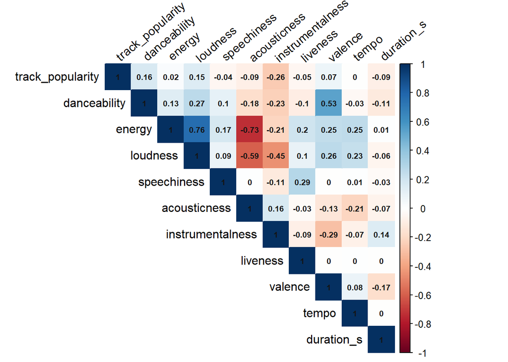

If you look at the correlation plot, you will notice that we don’t have many audio features strongly correlated with track popularity. This was quite obvious considering the wide range of music we have. However, danceability shows a positive association with track popularity and instrumentalness shows a negative correlation with the popularity.

```
##  track_popularity  danceability        energy          loudness
##  Min.   : 0.00    Min.   :0.0000   Min.   :0.0000   Min.   :-49.531
##  1st Qu.:37.00    1st Qu.:0.4450   1st Qu.:0.4570   1st Qu.:-10.459
##  Median :48.00    Median :0.5710   Median :0.6740   Median : -7.185
##  Mean   :46.91    Mean   :0.5593   Mean   :0.6334   Mean   : -8.526
##  3rd Qu.:59.00    3rd Qu.:0.6920   3rd Qu.:0.8530   3rd Qu.: -5.041
##  Max.   :99.00    Max.   :0.9930   Max.   :1.0000   Max.   :  1.893
##   speechiness       acousticness     instrumentalness      liveness
##  Min.   :0.00000   Min.   :0.00000   Min.   :0.000000   Min.   :0.0000
##  1st Qu.:0.03590   1st Qu.:0.01405   1st Qu.:0.000000   1st Qu.:0.0959
##  Median :0.04880   Median :0.16100   Median :0.000133   Median :0.1270
##  Mean   :0.08784   Mean   :0.31405   Mean   :0.173020   Mean   :0.2038
##  3rd Qu.:0.08630   3rd Qu.:0.59800   3rd Qu.:0.115000   3rd Qu.:0.2580
##  Max.   :0.96300   Max.   :0.99600   Max.   :1.000000   Max.   :0.9950
##     valence           tempo        time_signature
##  Min.   :0.0000   Min.   :  0.00   Min.   :0.000
##  1st Qu.:0.2440   1st Qu.: 98.74   1st Qu.:4.000
##  Median :0.4490   Median :121.83   Median :4.000
##  Mean   :0.4656   Mean   :121.72   Mean   :3.902
##  3rd Qu.:0.6790   3rd Qu.:140.05   3rd Qu.:4.000
##  Max.   :1.0000   Max.   :219.45   Max.   :5.000
##    duration_s
##  Min.   :8.213s
##  1st Qu.:184.379s (~3.07 minutes)
##  Median :223.039s (~3.72 minutes)
##  Mean   :237.857286939508s (~3.96 minutes)
##  3rd Qu.:271.6735s (~4.53 minutes)
##  Max.   :4719.013s (~1.31 hours)
```

Based on the summary statistics of the tracks, almost all the songs seem to have a common Time-Signature of 4/4. Hence, this parameter was dropped from the analysis. Most of the songs seem to have a value close to or equal to 0 for Instrumentalness. Since we saw the negative correlation in popularity of a song and instrumentalness, I decided to keep this. Energy and loudness seem highly proportional.

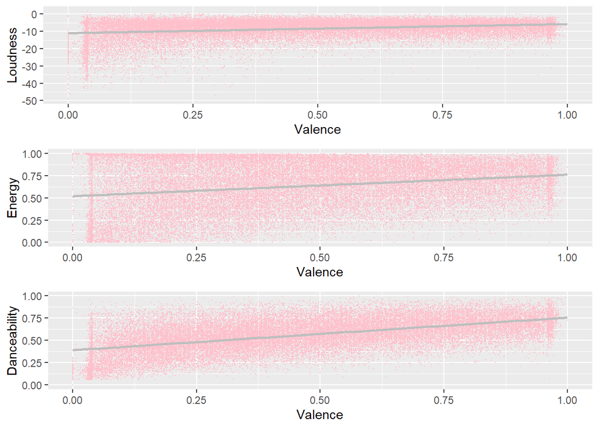

Considering the summary statistics, explored relationship of Valence with danceability, energy and loudness. Valence seems to be proportional to all of them.Which means more the tracks are energetic, loud and danceable more they are positive and mood uplifting. This is a quite obvious yet interesting insight.

Based on the observations above, I am interested in finding what all audio features make up to a positive and uplifting song. Also, can we find the secret ingredients to the most popular songs.

# Statistical Analysis

I wanted to know if happy, cheerful songs are preferred for dances and being a high valence makes a track more popular? These findings seem intuitive however, if we can back them with statistical analysis we will be sure about it.

Question 1: Is there significant mean difference in danceability, track popularity between the tracks with high valence and low valence?

Before conducting a t-test to answer above question I checked for normality of these audio features which showed some correlation with Valence. Valence is divided into two groups such as high valence and low valence on the basis of it’s mean value of 0.46.

```
##
##  high   low
## 18144 19122
```

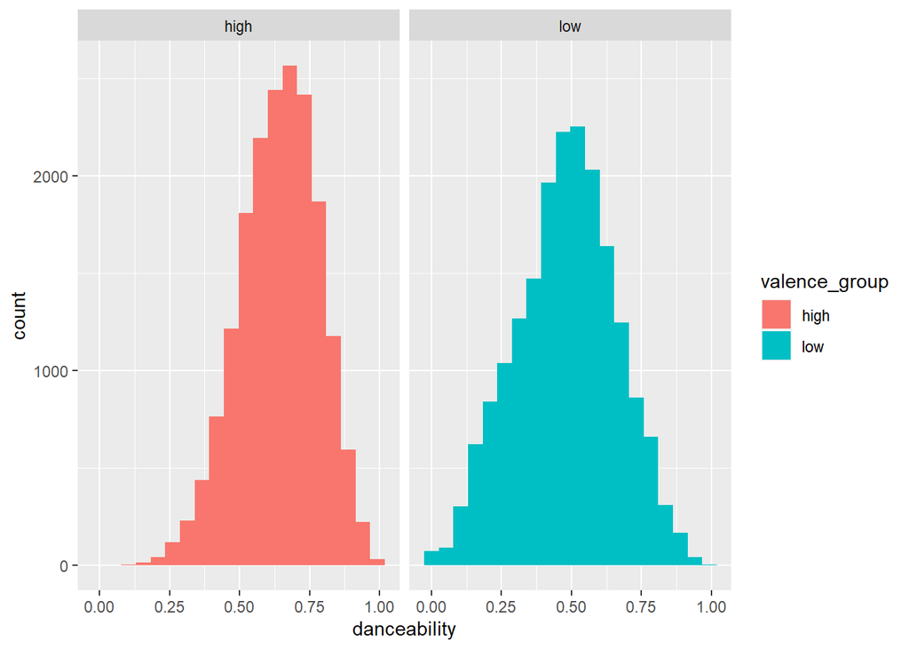

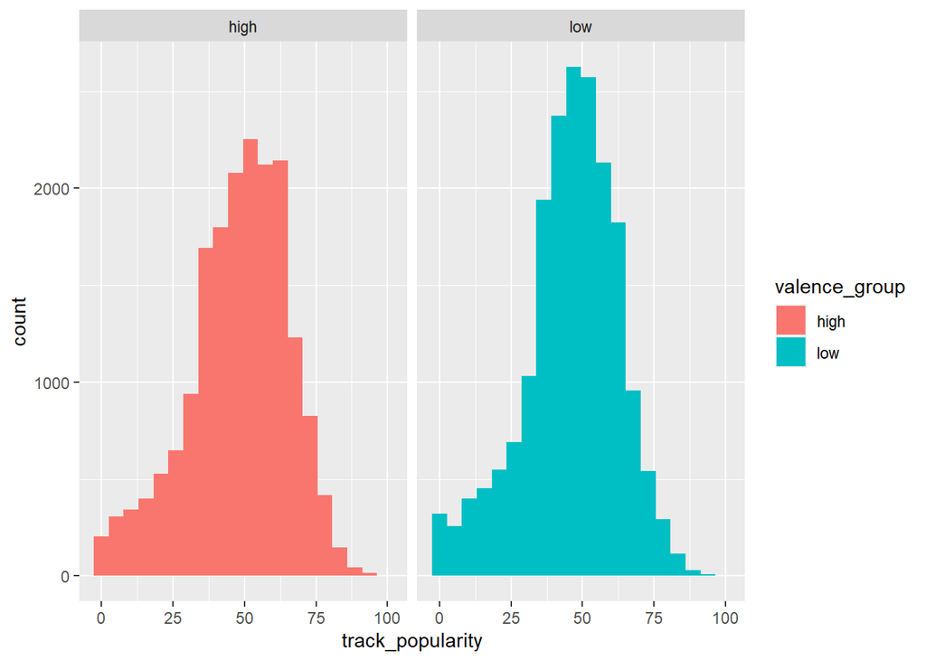

Since we see that danceability, track popularty seem to have a pretty normal distribution. Let’s conduct a hypothesis test to find out the mean difference between these audio features in valence groups grouped as high and low:

Null Hypothesis: There is mean difference in danceability, track popularity of tracks and when valence is high and when valence is low. Alternative Hypothesis: There is not a mean difference in danceability, track popularity of tracksand when valence is high and when valence is low.

```
##   p-value       low      high
## 0.0000000 0.1557801 0.1623062
```

```
##      p-value          low         high
## 6.084847e-31 1.695172e+00 2.386144e+00
```

Similarly, it would be interesting to know if a cheerful song has more lyrics or a sad/depressing song tends to be having more speechiness.

Question 2: Is there significant mean difference in speechiness with high valence tracks and low valence tracks?

Let’s conduct a t-test for this.

Null Hypothesis: There is mean difference in speechiness and when tracks have high valence as opposed to low valence. Alternative Hypothesis: There is not a mean difference in speechiness and when tracks have high valence as opposed to low valence.

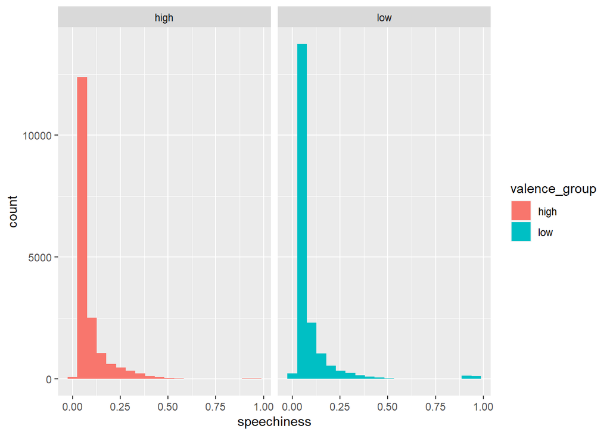

Looking at the distribution of speeciness, we can tell that both high valence and low valence songs tend to have a similar distribution.

```
##       p-value           low          high
##  0.0659341141 -0.0001440085  0.0045175121
```

# Regression Model:

Acousticness is an estimation of how acoustic a particular song is. High ‘acousticness’ consist mostly of natural acoustic sounds (e.g. acoustic guitar, piano, orchestra, the unprocessed human voice) Low ‘acousticness’ consists of mostly electric sounds (e.g. electric guitars, synthesizers, drum machines, auto-tuned vocals and so on). Dance music is normally highly processed. Pop, rap and hip-hop songs are not necessarily acoustic. How does acousticness affect a song’s popularity? Let’s see.

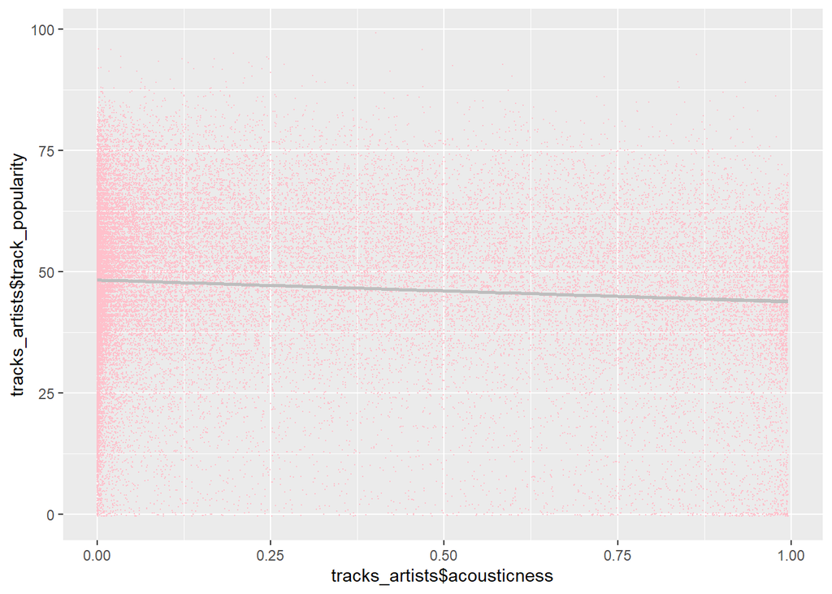

Accousticness is negatively correlated with track popularity. We checked this with a linear regression track popularity being response variable and accousticness being the only predictor.

H0: There’s no significant correlation between the popularity and the acousticness.

H1: there is some correlation between the popularity and the acousticness.

```
##
## Call:
## lm(formula = track_popularity ~ acousticness, data = tracks_artists)
##
## Residuals:
##     Min      1Q  Median      3Q     Max
## -48.318  -9.316   1.685  11.740  52.484
##
## Coefficients:
##              Estimate Std. Error t value Pr(>|t|)
## (Intercept)   48.3179     0.1198   403.2   <2e-16 ***
## acousticness  -4.4938     0.2598   -17.3   <2e-16 ***
## ---
## Signif. codes:  0 '***' 0.001 '**' 0.01 '*' 0.05 '.' 0.1 ' ' 1
##
## Residual standard error: 16.95 on 37309 degrees of freedom
## Multiple R-squared:  0.007956,   Adjusted R-squared:  0.007929
## F-statistic: 299.2 on 1 and 37309 DF,  p-value: < 2.2e-16
```

From the summary of the regression we can tell that with coefficient of -4.50, with every unit increase in accousticness, track popularity will decrease in by 4.5 units. However, the R-squared value for this model is really low hence we can not reply on this one.

Let’s move on to another audio feature danceability, as dance music is quite popular I want to test the correlation between these two. Daceability is pretty self-explanatory, it describes how suitable a track is for dancing based on a combination of musical elements including tempo, rhythm stability, beat strength, and overall regularity. A value of 0.0 is least danceable and 1.0 is most danceable.

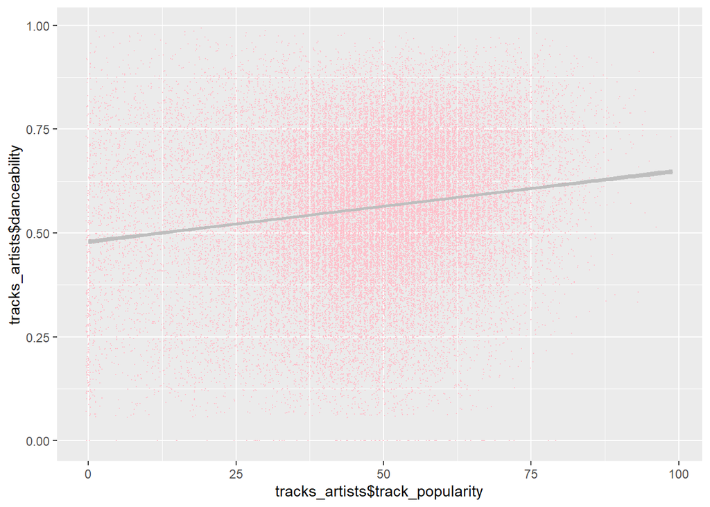

There is positive correlation between thh danceability and popularity. H0: There’s no significant correlation between the popularity and the danceability; H1: there is some correlation between the popularity and the danceability

```
##
## Call:
## lm(formula = track_popularity ~ danceability, data = tracks_artists)
##
## Residuals:
##     Min      1Q  Median      3Q     Max
## -52.972  -9.374   1.802  11.510  49.785
##
## Coefficients:
##              Estimate Std. Error t value Pr(>|t|)
## (Intercept)   38.3752     0.2837  135.27   <2e-16 ***
## danceability  15.2527     0.4828   31.59   <2e-16 ***
## ---
## Signif. codes:  0 '***' 0.001 '**' 0.01 '*' 0.05 '.' 0.1 ' ' 1
##
## Residual standard error: 16.79 on 37309 degrees of freedom
## Multiple R-squared:  0.02605,    Adjusted R-squared:  0.02603
## F-statistic: 998.1 on 1 and 37309 DF,  p-value: < 2.2e-16
```

Similarly we can check for all the audio features and use step-wise feature selection method to see which features are most correlated with popularity of the song.

Creating a multiple linear regression model with track_popularity value as the response variable and danceability, energy, key, loudness, mode, speechiness, acousticness, instrumentalness, liveness, valence, tempo and duration_ms as the covariates.

```
##
## Call:
## lm(formula = track_popularity ~ danceability + energy + key +
##     loudness + mode + speechiness + acousticness + instrumentalness +
##     liveness + valence + tempo + duration_ms, data = tracks_artists)
##
## Residuals:
##     Min      1Q  Median      3Q     Max
## -55.253  -8.996   1.591  11.062  61.731
##
## Coefficients:
##                    Estimate Std. Error t value Pr(>|t|)
## (Intercept)       5.908e+01  8.751e-01  67.510  < 2e-16 ***
## danceability      1.160e+01  5.923e-01  19.582  < 2e-16 ***
## energy           -1.012e+01  6.713e-01 -15.075  < 2e-16 ***
## key               1.519e-02  2.377e-02   0.639 0.522910
## loudness          2.911e-01  2.846e-02  10.229  < 2e-16 ***
## mode              4.664e-01  1.768e-01   2.638 0.008333 **
## speechiness      -8.698e+00  7.942e-01 -10.951  < 2e-16 ***
## acousticness     -5.342e+00  3.839e-01 -13.914  < 2e-16 ***
## instrumentalness -1.188e+01  3.141e-01 -37.836  < 2e-16 ***
## liveness         -1.678e+00  5.036e-01  -3.332 0.000863 ***
## valence          -4.450e+00  4.056e-01 -10.971  < 2e-16 ***
## tempo            -8.698e-03  2.897e-03  -3.002 0.002684 **
## duration_ms      -9.135e-06  8.465e-07 -10.793  < 2e-16 ***
## ---
## Signif. codes:  0 '***' 0.001 '**' 0.01 '*' 0.05 '.' 0.1 ' ' 1
##
## Residual standard error: 16.15 on 37298 degrees of freedom
## Multiple R-squared:  0.09989,    Adjusted R-squared:  0.0996
## F-statistic: 344.9 on 12 and 37298 DF,  p-value: < 2.2e-16
```

To choose a subset of the predictors let’s take a variable section approach. However, We are performing variable selection process to identify the significant covariates.

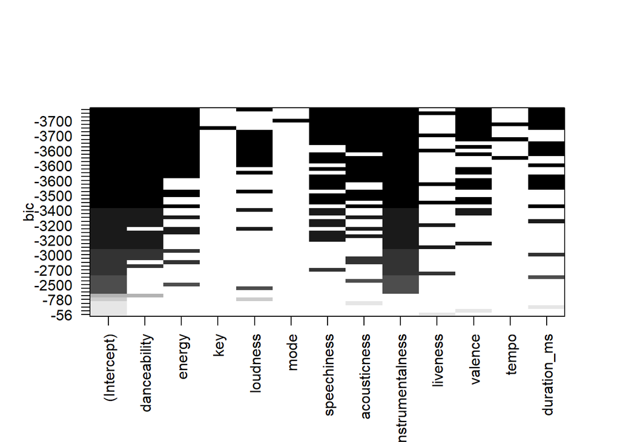

According to best subset selection, the influence of ‘Energy’ > ‘Loudness’.

```
##
## Call:
## lm(formula = track_popularity ~ danceability + energy + loudness +
##     mode + speechiness + acousticness + instrumentalness + liveness +
##     valence + tempo + duration_ms, data = tracks_artists)
##
## Residuals:
##     Min      1Q  Median      3Q     Max
## -55.239  -8.980   1.593  11.072  61.673
##
## Coefficients:
##                    Estimate Std. Error t value Pr(>|t|)
## (Intercept)       5.917e+01  8.645e-01  68.441  < 2e-16 ***
## danceability      1.160e+01  5.923e-01  19.581  < 2e-16 ***
## energy           -1.012e+01  6.713e-01 -15.074  < 2e-16 ***
## loudness          2.912e-01  2.845e-02  10.235  < 2e-16 ***
## mode              4.506e-01  1.750e-01   2.574 0.010048 *
## speechiness      -8.695e+00  7.942e-01 -10.948  < 2e-16 ***
## acousticness     -5.343e+00  3.839e-01 -13.915  < 2e-16 ***
## instrumentalness -1.188e+01  3.141e-01 -37.836  < 2e-16 ***
## liveness         -1.680e+00  5.036e-01  -3.335 0.000852 ***
## valence          -4.444e+00  4.055e-01 -10.959  < 2e-16 ***
## tempo            -8.692e-03  2.897e-03  -3.000 0.002702 **
## duration_ms      -9.134e-06  8.464e-07 -10.791  < 2e-16 ***
## ---
## Signif. codes:  0 '***' 0.001 '**' 0.01 '*' 0.05 '.' 0.1 ' ' 1
##
## Residual standard error: 16.15 on 37299 degrees of freedom
## Multiple R-squared:  0.09988,    Adjusted R-squared:  0.09962
## F-statistic: 376.3 on 11 and 37299 DF,  p-value: < 2.2e-16
```

Let’s check if these models are adequate.

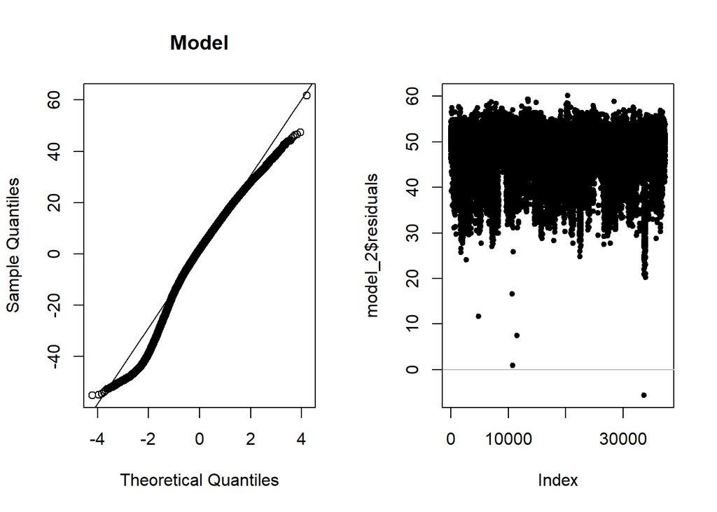

From the graphs, we observe that the qq plot is not ideal, and the data in the scatterplot is not evenly distributed.

Therefore, this data set doesn’t completely satisfy the normality, linearity and equal variance assumptions.

# Conclusion

# Future Scope

We can improve the model by applying transformations on the dependent variable and covariants. We will be able to get a better model for prediction analysis

Combining different datasets related to music apart from the Spotify data wil be helpful in better analysis of the song’s popularity.

# References:

- https://towardsdatascience.com/tagged/spotify
- https://opendatascience.com/a-machine-learning-deep-dive-into-my-spotify-data/
- https://www.reisanar.com/files/poster_Benito_Carr_v5.pdf